# v_plants — Paired Resurvey Analysis

Valtýr

2026-03-20

```r
library(tidyverse)
library(vegan)
library(broom)
library(ggrepel)
library(indicspecies)
library(knitr)

set.seed(123)
```

```r
# Always source the prep script. NMDS caching is handled inside prep itself —
# it checks for outputs/nmds_strict_cache.rds and loads or recomputes as needed,
# so sourcing prep is fast when the cache exists.
prep_script <- "v_plants_prep.R"
if (!file.exists(prep_script)) {
  stop("Required script not found: ", prep_script)
}
source(prep_script, local = .GlobalEnv)
```

> **Purpose.** This document picks up directly after `v_plants_variable_screening.html`. All core objects are created by `v_plants_prep.R` (sourced above); the screening document is an audit trail that describes how they were selected and filtered.

> | Object | Description |
> | --- | --- |
> | `community_long_paired` | Long-format cover table (plot × sample × taxon) |
> | `community_wide_strict` | Wide community matrix with `plot_number` + `sample` columns |
> | `meta_strict` | Metadata aligned row-for-row with `community_wide_strict` |
> | `mat_strict` | Numeric species matrix (322 rows × 222 cols) |
> | `nmds_strict` | `metaMDS` result on `mat_strict` (all plots, pre-outlier removal) |
> | `fit_strict` | `envfit` result on `nmds_strict` |
> | `vars_driver_strict_final`, `driver_final` | Variable vectors from screening |

## Analytical strategy — why NMDS first, then RDA?

The distinction comes down to what question each method is designed to answer.

**NMDS** is unconstrained — the ordination axes are determined entirely by the species composition data. The community structure emerges first, and you then ask whether environmental variables happen to correlate with it (envfit). The question is: *what is the main structure of variation in these communities, and does anything we measured line up with it?* Nothing is assumed about which variables matter or how they relate to composition. This is the right starting point for a dataset spanning many habitat types across Iceland, where you don’t yet know which gradients dominate.

**RDA/dbRDA** is constrained — the axes are forced to be linear combinations of the predictors you specify. It can only show you the variation in composition that is mathematically explainable by those specific variables. The question shifts to: *how much of the community variance do these predictors formally account for, and can I partition it cleanly?*

**The core argument for using both in sequence in this dataset.** The paired temporal design means there are two distinct signals sitting on top of each other: the baseline ecological gradient (wet vs dry, deep soil vs shallow, etc.) and the change between first and last survey. NMDS with PERMANOVA establishes that a temporal signal exists at all — that communities at the last survey are measurably different from their own baseline. That is a prerequisite worth demonstrating on its own before asking what drove the change.

RDA/dbRDA with `Condition(plot_number)` then partitions the temporal component away from the among-plot gradient. By conditioning on plot identity you remove the dominant baseline variation — the fact that a heath plot and a wetland plot are just compositionally different — and look only at within-plot change over time. That is where a variable like `haplontuthekja` (vascular plant cover) becomes a legitimate predictor rather than a circular one. You are not asking “do plots with more vascular cover have different communities?” (which is trivially true), you are asking “did plots whose vascular cover *changed* show corresponding compositional shifts?”

In short: NMDS describes the landscape of variation; RDA partitions it into sources. Using RDA without NMDS first would risk constraining the ordination to variables that miss the dominant gradients entirely.

# Part 1 — Preliminary NMDS (all plots)

## 1.1 Ordination plot

This first pass runs on the full 161-plot dataset before any outlier removal. It is included here as a diagnostic to show why the three coastal/dune plots need special treatment.

```r
# Extract site scores
nmds_scores <- as.data.frame(scores(nmds_strict, display = "sites")) %>%
  bind_cols(meta_strict %>% select(plot_number, sample))

# Build envfit data including gap_years in addition to the strict drivers
# Exploratory columns (gap_years, grytnithekja) use any_of() so they are silently
# dropped if absent from meta_strict (meta_strict only carries vars_driver_strict_final
# + extra_env_exploratory; grytnithekja is available in env_candidates_ps / v_plants_use
# but is not pulled into meta_strict by default).
env_all <- meta_strict %>%
  select(
    all_of(vars_driver_strict_final),          # required core drivers
    any_of(c(
      "gap_years",                             # time gap effect
      #"habitat_type_name",                   # broader habitat grouping
      "grytnithekja"                           # exploratory rock cover (if present)
    ))
  ) %>%
  mutate(
    across(where(is.character), as.factor),
    across(where(is.logical),   as.factor)
  )

fit_all <- vegan::envfit(nmds_strict, env_all, permutations = 999, na.rm=T)

# --- envfit arrows (continuous vectors) ---
sig_thresh <- 0.05

vec_df <- tibble(variable = character(), NMDS1 = numeric(), NMDS2 = numeric(),
                 r2 = numeric(), p_value = numeric(), kind = character())

if (!is.null(fit_all$vectors) && !is.null(fit_all$vectors$arrows)) {
  vec_raw  <- as.data.frame(fit_all$vectors$arrows) %>%
    rownames_to_column("variable")
  vec_axes <- setdiff(names(vec_raw), "variable")
  if (length(vec_axes) >= 2) {
    vec_df <- vec_raw %>%
      rename(NMDS1 = all_of(vec_axes[1]), NMDS2 = all_of(vec_axes[2])) %>%
      select(variable, NMDS1, NMDS2) %>%
      mutate(
        r2      = as.numeric(fit_all$vectors$r[variable]),
        p_value = as.numeric(fit_all$vectors$pvals[variable]),
        kind    = "numeric"
      )
  }
}

# --- envfit factor centroids ---
fac_df <- tibble(variable = character(), NMDS1 = numeric(), NMDS2 = numeric(),
                 r2 = numeric(), p_value = numeric(), kind = character())

if (!is.null(fit_all$factors) && !is.null(fit_all$factors$centroids)) {
  fac_raw  <- as.data.frame(fit_all$factors$centroids) %>%
    rownames_to_column("variable")
  fac_axes <- setdiff(names(fac_raw), "variable")
  if (length(fac_axes) >= 2) {
    fac_df <- fac_raw %>%
      rename(NMDS1 = all_of(fac_axes[1]), NMDS2 = all_of(fac_axes[2])) %>%
      select(variable, NMDS1, NMDS2) %>%
      mutate(r2 = NA_real_, p_value = NA_real_, kind = "factor")
  }
}

arrow_df_all <- bind_rows(vec_df, fac_df) %>%
  filter(is.na(p_value) | p_value <= sig_thresh)

ordi_radius_all <- max(abs(c(nmds_scores$NMDS1, nmds_scores$NMDS2))) * 0.7

arrow_df_all <- arrow_df_all %>%
  mutate(xend = NMDS1 * ordi_radius_all,
         yend = NMDS2 * ordi_radius_all)

# One label per plot at midpoint between first and last survey
nmds_plot_labels <- nmds_scores %>%
  group_by(plot_number) %>%
  summarise(NMDS1 = mean(NMDS1), NMDS2 = mean(NMDS2), .groups = "drop")

pnmds <- ggplot(nmds_scores, aes(x = NMDS1, y = NMDS2)) +
  geom_line(aes(group = plot_number),
            colour = "grey70", linewidth = 0.3, alpha = 0.6) +
  geom_point(aes(colour = sample, shape = sample),
             size = 2.0, alpha = 0.85) +
  geom_text_repel(
    data = nmds_plot_labels,
    aes(x = NMDS1, y = NMDS2, label = plot_number),
    size = 1.7, colour = "grey35",
    segment.size = 0.2, segment.colour = "grey60",
    max.overlaps = Inf, seed = 77, inherit.aes = FALSE
  ) +
  geom_segment(
    data = arrow_df_all %>% filter(kind == "numeric"),
    aes(x = 0, y = 0, xend = xend, yend = yend),
    arrow = arrow(length = unit(0.2, "cm")),
    colour = "#c0392b", linewidth = 0.7, inherit.aes = FALSE
  ) +
  geom_label_repel(
    data = arrow_df_all %>% filter(kind == "numeric"),
    aes(x = xend * 1.1, y = yend * 1.1, label = variable),
    size = 2.8, colour = "#c0392b",
    fill = alpha("white", 0.7), label.size = 0,
    max.overlaps = 20, seed = 42, inherit.aes = FALSE
  ) +
  scale_colour_manual(values = c(first = "#2980b9", last = "#e67e22"),
                      labels = c(first = "First survey", last = "Last survey")) +
  scale_shape_manual(values  = c(first = 16, last = 17),
                     labels  = c(first = "First survey", last = "Last survey")) +
  labs(
    title    = "NMDS of plant community composition (Bray–Curtis) — all plots",
    subtitle = sprintf(
      "%d plots · stress = %.3f · paired PERMANOVA R² = %.1f%%, p = %.3f",
      length(unique(nmds_scores$plot_number)),
      nmds_strict$stress,
      perm_strict[1, "R2"] * 100,
      perm_strict[1, "Pr(>F)"]
    ),
    x = "NMDS1", y = "NMDS2", colour = NULL, shape = NULL,
    caption = "Arrows: envfit vectors (p ≤ 0.05). Lines connect first and last survey of the same plot."
  ) +
  theme_classic(base_size = 11) +
  theme(legend.position = "bottom")
```

```r
# Paired PERMANOVA: does community composition differ between first and last survey?
# strata = plot_number ensures permutations are constrained within plots (paired design).
# Row 1 = predictor (labelled "Model" in vegan ≥ 2.6, "sample" in older versions)
# Row 2 = Residual — use row index rather than name for version robustness
perm_r2  <- round(perm_strict[1, "R2"] * 100, 1)
perm_p   <- perm_strict[1, "Pr(>F)"]
perm_f   <- round(perm_strict[1, "F"], 2)
perm_df1 <- perm_strict[1, "Df"]
perm_df2 <- perm_strict[2, "Df"]

cat(sprintf(
  "Paired PERMANOVA (adonis2, Bray–Curtis, strata = plot):\n  F(%d, %d) = %.2f,  R² = %.1f%%,  p = %.3f\n",
  perm_df1, perm_df2, perm_f, perm_r2, perm_p
))
```

```
## Paired PERMANOVA (adonis2, Bray–Curtis, strata = plot):
##   F(1, 320) = 8.74,  R² = 2.7%,  p = 0.001
```

```r
print(perm_strict)
```

```
## Permutation test for adonis under reduced model
## Blocks:  strata
## Permutation: free
## Number of permutations: 999
##
## vegan::adonis2(formula = mat_strict ~ sample, data = meta_strict, permutations = 999, method = "bray", strata = meta_strict$plot_number)
##           Df SumOfSqs      R2      F Pr(>F)
## Model      1    3.491 0.02659 8.7416  0.001 ***
## Residual 320  127.799 0.97341
## Total    321  131.291 1.00000
## ---
## Signif. codes:  0 '***' 0.001 '**' 0.01 '*' 0.05 '.' 0.1 ' ' 1
```

**What the test did.** Each plot was surveyed twice — once early, once late. The test asks: are the two surveys from the same plot more similar to each other than they are to surveys of other plots at different times? Permutations were constrained within each plot (`strata = plot_number`), so the test is genuinely paired — it can only detect change *within* plots, not just differences *between* them.

**F(1, 320) = 8.74.** The F-statistic compares the variance explained by survey timing (first vs last) to the residual variance. 8.74 is well above 1, meaning the temporal effect is real and not lost in noise. The degrees of freedom tell you the design: 1 for the predictor (survey: first or last), 320 for the residual (161 plots × 2 surveys − 2).

**R² = 2.7%.** This is the important one to interpret carefully. It does *not* mean the temporal change is weak or unimportant. It means that out of all the compositional variation in the dataset — the enormous differences between a highland heath, a wetland, a lava field, and a birch shrubland — 2.7% is attributable to the first-vs-last contrast. The remaining ~97.3% is the baseline variation *between* plots, which dwarfs the within-plot change. This is completely normal and expected in a paired vegetation study spanning many habitat types. The paired design was chosen precisely because it strips out that dominant between-plot variation and focuses on the within-plot signal.

**p = 0.001.** With 999 permutations this is the minimum achievable p-value, meaning none of the 999 random reshufflings produced an F as large as 8.74. The temporal signal is statistically unambiguous.

**In plain terms.** Icelandic plant communities changed measurably between their first and last survey. The change is real and consistent enough to survive a rigorous paired permutation test. It is small relative to the total variation in the dataset, which is expected — a heath is still a heath after ten years, it just has a slightly different species mix. The R² is not a measure of ecological importance; it is a measure of how much of the total dataset variance this one contrast accounts for. The F-statistic and p-value are what establish whether the change is real.

## 1.2 Outlier identification

```r
# Data‑driven outlier detection on the all‑plots NMDS
nmds_scores_all <- as.data.frame(scores(nmds_strict, display = "sites")) %>%
  bind_cols(meta_strict %>% select(plot_number, sample))

# 1) Distance from the NMDS centroid
centroid <- colMeans(nmds_scores_all[, c("NMDS1", "NMDS2")])
nmds_scores_all <- nmds_scores_all %>%
  mutate(dist_center = sqrt((NMDS1 - centroid["NMDS1"])^2 +
                            (NMDS2 - centroid["NMDS2"])^2))

# 2) Flag plots whose distance is in the top tail (e.g. top 3 plots)
outlier_plots <- nmds_scores_all %>%
  arrange(desc(dist_center)) %>%
  distinct(plot_number, .keep_all = TRUE) %>%
  slice_head(n = 3) %>%                # or use a threshold on dist_center
  pull(plot_number)

# Inspect which plots were flagged
outlier_plots
```

```
## [1] "RN-03"    "RN-02"    "RN-24-03"
```

```r
meta_outliers <- meta_strict %>%
  filter(plot_number %in% outlier_plots) %>%
  select(
    plot_number, sample,
    any_of(c("soil_depth", "grytnithekja",
             "vegetation_height_mean", "soil_type_name",
             "moisture_name", "topography_name"))
  )

print_full(
  meta_outliers,
  caption = "Metadata for automatically detected outlier plots (both surveys)."
)
```

Metadata for automatically detected outlier plots (both surveys).

| plot_number | sample | soil_depth | soil_type_name | moisture_name | topography_name |
| --- | --- | --- | --- | --- | --- |
| RN-02 | first | 115 | Sandjörð | Þurrlendi | Jafnlendi |
| RN-02 | last | 110 | Sandjörð | Þurrlendi | Jafnlendi |
| RN-03 | first | 115 | Sandjörð | Þurrlendi | Jafnlendi |
| RN-03 | last | 110 | Sandjörð | Þurrlendi | Jafnlendi |
| RN-24-03 | first | 115 | Sandjörð | Þurrlendi | Jafnlendi |
| RN-24-03 | last | 115 | Sandjörð | Þurrlendi | Jafnlendi |

```r
# Which taxa are responsible for the outlier separation?
# Compare mean relative abundance in outlier vs non-outlier rows.
outlier_rows     <- meta_strict$plot_number %in% outlier_plots
mat_rel          <- mat_strict / rowSums(mat_strict)

taxa_shift <- tibble(
  taxon               = colnames(mat_strict),
  mean_rel_outlier    = colMeans(mat_rel[outlier_rows,  , drop = FALSE]),
  mean_rel_non_outlier = colMeans(mat_rel[!outlier_rows, , drop = FALSE])
) %>%
  mutate(delta_rel = mean_rel_outlier - mean_rel_non_outlier) %>%
  arrange(desc(abs(delta_rel)))

print_full(taxa_shift %>% slice_head(n = 30),
           caption = "Top 30 taxa driving the outlier separation (|Δ relative abundance|).")
```

Top 30 taxa driving the outlier separation (|Δ relative abundance|).

| taxon | mean_rel_outlier | mean_rel_non_outlier | delta_rel |
| --- | --- | --- | --- |
| Leymus arenarius | 0.3075 | 0.0006 | 0.3070 |
| Armeria maritima | 0.1902 | 0.0100 | 0.1801 |
| Honckenya peploides | 0.1555 | 0.0000 | 0.1555 |
| Mertensia maritima | 0.1399 | 0.0000 | 0.1399 |
| Cakile maritima | 0.1227 | 0.0000 | 0.1227 |
| Empetrum nigrum | 0.0000 | 0.0664 | -0.0664 |
| Carex nigra | 0.0000 | 0.0617 | -0.0617 |
| Carex lyngbyei | 0.0000 | 0.0484 | -0.0484 |
| Festuca rubra | 0.0000 | 0.0439 | -0.0439 |
| Salix arctica | 0.0000 | 0.0425 | -0.0425 |
| Racomitrium lanuginosum | 0.0000 | 0.0392 | -0.0392 |
| Vaccinium uliginosum | 0.0000 | 0.0374 | -0.0374 |
| Silene uniflora | 0.0385 | 0.0018 | 0.0367 |
| Eriophorum angustifolium | 0.0000 | 0.0364 | -0.0364 |
| Agrostis stolonifera | 0.0000 | 0.0338 | -0.0338 |
| Carex bigelowii | 0.0000 | 0.0304 | -0.0304 |
| Salix herbacea | 0.0000 | 0.0292 | -0.0292 |
| Carex rariflora | 0.0000 | 0.0289 | -0.0289 |
| Betula nana | 0.0000 | 0.0279 | -0.0279 |
| Carex rostrata | 0.0000 | 0.0252 | -0.0252 |
| Bistorta vivipara | 0.0000 | 0.0200 | -0.0200 |
| Calamagrostis neglecta | 0.0000 | 0.0193 | -0.0193 |
| Plantago maritima | 0.0277 | 0.0086 | 0.0191 |
| Puccinellia coarctata | 0.0000 | 0.0180 | -0.0180 |
| Festuca vivipara | 0.0000 | 0.0119 | -0.0119 |
| Juncus arcticus | 0.0000 | 0.0106 | -0.0106 |
| Equisetum variegatum | 0.0000 | 0.0098 | -0.0098 |
| Carex chordorrhiza | 0.0000 | 0.0095 | -0.0095 |
| Equisetum arvense | 0.0000 | 0.0094 | -0.0094 |
| Equisetum palustre | 0.0000 | 0.0094 | -0.0094 |

# Part 2 — Core NMDS (outliers excluded)

```r
keep_rows <- !meta_strict$plot_number %in% outlier_plots
meta_core <- meta_strict[keep_rows, ]
mat_core  <- mat_strict[keep_rows, ]

# Drop taxa that only occurred in the removed plots
taxa_present <- colSums(mat_core) > 0
mat_core     <- mat_core[, taxa_present]
```

## 2.1 Re-run NMDS

```r
nmds_core <- metaMDS(
  mat_core,
  distance = "bray",
  k        = 2,
  trymax   = 200,
  trace    = FALSE
)
```

**NMDS stress (core, k = 2): 0.196**

> Stress interpretation: **Acceptable** — ordination is usable; mention stress in figure caption.

For interpretation, we use the **2D NMDS (`nmds_core`) with `fit_core` arrows** as the main ordination figure. The arrows show which environmental gradients best align with the dominant compositional axes.

### Shepard plot

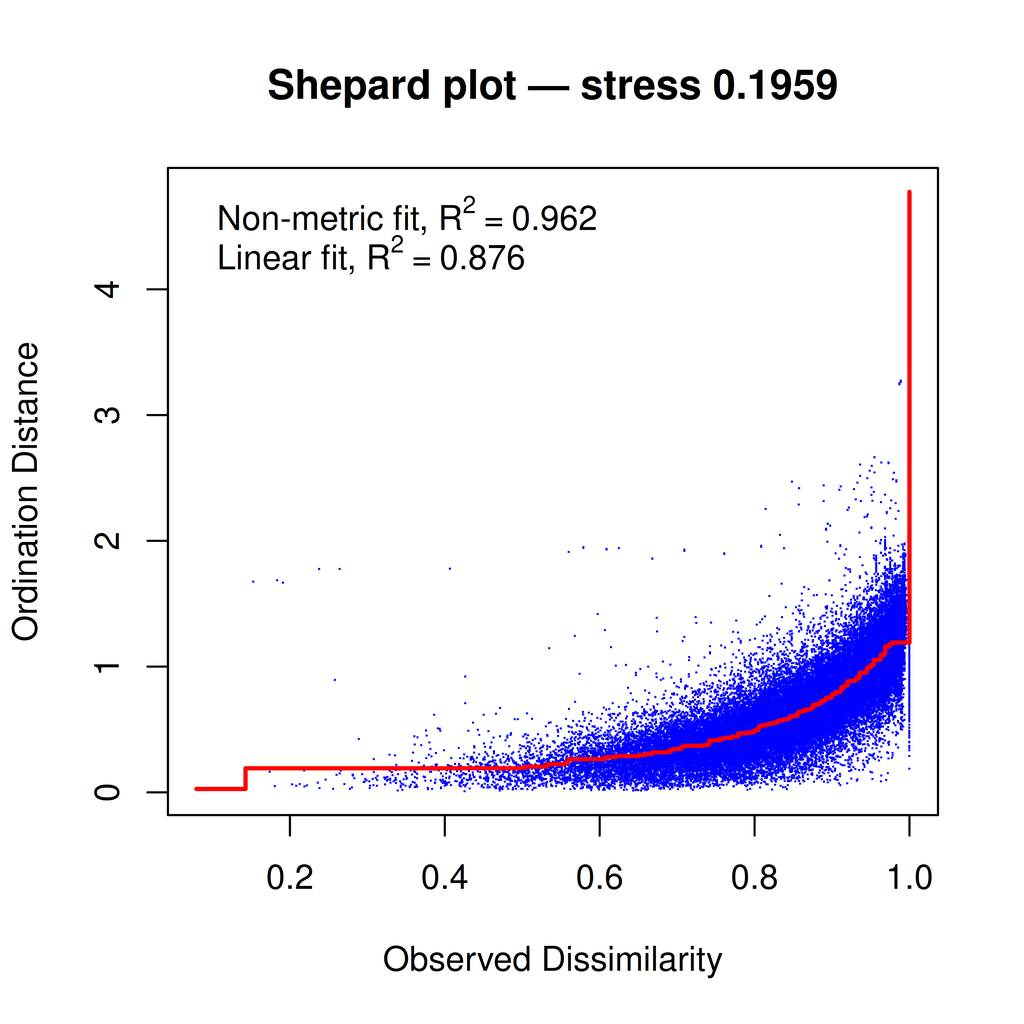

Shepard diagram: ordination distances vs. dissimilarities. Points should follow the step function tightly.

```r
stressplot(nmds_core,
           main = sprintf("Shepard plot — stress %.4f", nmds_core$stress))
```

## 2.2 Re-fit environmental vectors

```r
env_core <- meta_core %>%
  select(all_of(vars_driver_strict_final)) %>%
  mutate(
    across(where(is.character), as.factor),
    across(where(is.logical),   as.factor)
  )

fit_core <- envfit(nmds_core, env_core, permutations = 999)
```

```r
fit_tbl_core <- bind_rows(
  tibble(
    variable = names(fit_core$vectors$r),
    r2       = as.numeric(fit_core$vectors$r),
    p_value  = as.numeric(fit_core$vectors$pvals),
    kind     = "numeric"
  ),
  if (!is.null(fit_core$factors)) tibble(
    variable = names(fit_core$factors$r),
    r2       = as.numeric(fit_core$factors$r),
    p_value  = as.numeric(fit_core$factors$pvals),
    kind     = "factor"
  )
) %>%
  arrange(p_value) %>%
  mutate(sig = case_when(p_value < 0.001 ~ "***",
                         p_value < 0.01  ~ "**",
                         p_value < 0.05  ~ "*",
                         TRUE            ~ "ns"))

print_full(fit_tbl_core,
           caption = "envfit results on core dataset (outliers removed). r² = goodness-of-fit.")
```

envfit results on core dataset (outliers removed). r² = goodness-of-fit.

| variable | r2 | p_value | kind | sig |
| --- | --- | --- | --- | --- |
| soil_depth | 0.3208 | 0.001 | numeric | ** |
| soil_type_name | 0.3446 | 0.001 | factor | ** |
| moisture_name | 0.2227 | 0.001 | factor | ** |
| topography_name | 0.0214 | 0.052 | factor | ns |
| permafrost | 0.0057 | 0.182 | factor | ns |

## 2.3 NMDS biplot

```r
# --- Build arrow data frame ---
sig_thresh <- 0.05

arrow_df_core <- as.data.frame(fit_core$vectors$arrows) %>%
  rownames_to_column("variable") %>%
  rename(ax1 = NMDS1, ax2 = NMDS2) %>%
  mutate(
    r2      = fit_core$vectors$r,
    p_value = fit_core$vectors$pvals
  ) %>%
  filter(p_value <= sig_thresh)

# Factor centroids
factor_df_core <- tryCatch({
  as.data.frame(scores(fit_core, display = "factors")) %>%
    rownames_to_column("label") %>%
    rename(fax1 = NMDS1, fax2 = NMDS2) %>%
    mutate(
      p_value = fit_core$factors$pvals[
        sapply(label, function(nm) {
          matched <- names(fit_core$factors$pvals)[startsWith(nm, names(fit_core$factors$pvals))]
          if (length(matched)) matched[1] else NA_character_
        })
      ]
    ) %>%
    filter(!is.na(p_value), p_value <= sig_thresh)
}, error = function(e) tibble())

# --- Site scores ---
site_scores <- as.data.frame(scores(nmds_core, display = "sites")) %>%
  bind_cols(meta_core %>% select(plot_number, sample))

ordi_radius_core <- max(abs(c(site_scores$NMDS1, site_scores$NMDS2))) * 0.70

arrow_df_core <- arrow_df_core %>%
  mutate(xend = ax1 * ordi_radius_core,
         yend = ax2 * ordi_radius_core)

# One label per plot at midpoint between first and last survey
core_plot_labels <- site_scores %>%
  group_by(plot_number) %>%
  summarise(NMDS1 = mean(NMDS1), NMDS2 = mean(NMDS2), .groups = "drop")

# --- Plot ---
p_nmds_core <- ggplot(site_scores, aes(x = NMDS1, y = NMDS2)) +
  geom_line(aes(group = plot_number),
            colour = "grey60", linewidth = 0.30, alpha = 0.55) +
  geom_point(aes(colour = sample, shape = sample),
             size = 2.0, alpha = 0.85) +
  geom_text_repel(
    data = core_plot_labels,
    aes(x = NMDS1, y = NMDS2, label = plot_number),
    size = 1.7, colour = "grey35",
    segment.size = 0.2, segment.colour = "grey60",
    max.overlaps = Inf, seed = 77, inherit.aes = FALSE
  ) +
  geom_segment(
    data = arrow_df_core,
    aes(x = 0, y = 0, xend = xend, yend = yend),
    arrow = arrow(length = unit(0.22, "cm"), type = "closed"),
    colour = "#c0392b", linewidth = 0.75, inherit.aes = FALSE
  ) +
  geom_label_repel(
    data        = arrow_df_core,
    aes(x = xend * 1.12, y = yend * 1.12, label = variable),
    size        = 3.0, colour = "#c0392b",
    fill        = alpha("white", 0.80), label.size = 0,
    max.overlaps = 20, seed = 42, inherit.aes = FALSE
  ) +
  {
    if (nrow(factor_df_core) > 0)
      geom_label_repel(
        data        = factor_df_core,
        aes(x = fax1, y = fax2, label = label),
        size        = 2.5, colour = "#27ae60",
        fill        = alpha("white", 0.80), label.size = 0,
        max.overlaps = 15, seed = 43, inherit.aes = FALSE
      )
  } +
  scale_colour_manual(values = c(first = "#2980b9", last = "#e67e22"),
                      labels = c(first = "First survey", last = "Last survey")) +
  scale_shape_manual(values  = c(first = 16, last = 17),
                     labels  = c(first = "First survey", last = "Last survey")) +
  coord_equal() +
  labs(
    title    = "NMDS — core dataset (Bray–Curtis)",
    subtitle = sprintf(
      "%d plots · stress = %.3f · excl. %s",
      length(unique(site_scores$plot_number)),
      nmds_core$stress,
      paste(outlier_plots, collapse = ", ")
    ),
    x = "NMDS1", y = "NMDS2", colour = NULL, shape = NULL,
    caption = "Red arrows: envfit vectors (p ≤ 0.05); length ∝ r².\nGrey lines connect first and last survey of the same plot."
  ) +
  theme_classic(base_size = 11) +
  theme(
    legend.position = "bottom",
    plot.subtitle   = element_text(size = 8, colour = "grey40"),
    plot.caption    = element_text(size = 7.5, colour = "grey50", hjust = 0)
  )


ggsave("outputs/p_nmds_core.png",
         plot = p_nmds_core,
         width  = 16,   # cm — square-ish canvas to match coord_equal() panel
         height = 17,   # cm — extra height for title + legend + caption
         units  = "cm",
         dpi    = 300,
         bg     = "white")
```

## 2.4 Trajectory plot: per-plot arrows, survey ellipses, dominant species

Three additions derived from the marine benthos analysis pipeline: - **Directed arrows** (first → last) replace undirected grey lines, making direction and magnitude of per-plot change readable directly from the ordination. - **70% normal ellipses** delimit the first- and last-survey community clouds, showing whether the two survey groups overlap or have separated in ordination space. - **Dominant species labels** (>1% relative abundance in `mat_core`) overlay the biplot, making the axes interpretable without consulting a separate species table.

```r
# --- Per-plot arrow data: pivot site scores to wide ---
traj_wide <- as.data.frame(scores(nmds_core, display = "sites")) %>%
  bind_cols(meta_core %>% select(plot_number, sample)) %>%
  pivot_wider(
    names_from  = sample,
    values_from = c(NMDS1, NMDS2),
    names_sep   = "_"
  ) %>%
  left_join(
    meta_core %>% filter(sample == "first") %>%
      select(plot_number, any_of("soil_type_name"), any_of("moisture_name")),
    by = "plot_number"
  ) %>%
  filter(complete.cases(NMDS1_first, NMDS2_first, NMDS1_last, NMDS2_last)) %>%
  mutate(traj_colour = if ("soil_type_name" %in% names(.)) soil_type_name
                       else if ("moisture_name" %in% names(.)) moisture_name
                       else "unknown")

# --- Dominant species scores (>1% relative abundance in mat_core) ---
rel_abund     <- colSums(mat_core) / sum(mat_core)
dominant_spp  <- names(rel_abund[rel_abund > 0.01])

sp_scores_dom <- as.data.frame(scores(nmds_core, display = "species")) %>%
  rownames_to_column("taxon") %>%
  filter(taxon %in% dominant_spp)

# --- Survey-group scores (for ellipses) ---
survey_scores <- as.data.frame(scores(nmds_core, display = "sites")) %>%
  bind_cols(meta_core %>% select(sample))

# --- Plot ---
p_nmds_traj <-  ggplot() +
  # Survey-group ellipses (70% normal): dashed = first, solid = last
  stat_ellipse(
    data      = survey_scores,
    aes(x = NMDS1, y = NMDS2, group = sample, linetype = sample),
    type      = "norm", level = 0.70,
    colour    = "grey45", linewidth = 0.55
  ) +
  # Per-plot trajectory arrows (first → last)
  geom_segment(
    data = traj_wide,
    aes(x = NMDS1_first, y = NMDS2_first,
        xend = NMDS1_last, yend = NMDS2_last,
        colour = traj_colour),
    arrow     = arrow(length = unit(0.18, "cm"), type = "closed"),
    linewidth = 0.45, alpha = 0.70
  ) +
  # Dominant species labels
  geom_text_repel(
    data = sp_scores_dom,
    aes(x = NMDS1, y = NMDS2, label = taxon),
    size = 2.5, colour = "grey20", fontface = "italic",
    max.overlaps = 30, seed = 55
  ) +
  scale_linetype_manual(
    values = c(first = "dashed", last = "solid"),
    labels = c(first = "First survey", last = "Last survey")
  ) +
  coord_equal() +
  labs(
    title    = "NMDS — per-plot compositional trajectories (first → last)",
    subtitle = sprintf("%d plots · Bray–Curtis · stress = %.3f",
                       nrow(traj_wide), nmds_core$stress),
    x        = "NMDS1",
    y        = "NMDS2",
    colour   = if ("soil_type_name" %in% names(traj_wide)) "Soil type" else "Moisture",
    linetype = "Survey ellipse",
    caption  = paste(
      "Arrows: first → last survey per plot, coloured by soil type or moisture (from first survey).",
      "Dashed/solid ellipses (70% normal): first/last survey community clouds.",
      "Italic text: taxa > 1% relative abundance in the core matrix.",
      sep = "\n"
    )
  ) +
  theme_classic(base_size = 11) +
  theme(
    legend.position = "bottom",
    legend.box      = "vertical",
    plot.subtitle   = element_text(size = 8,   colour = "grey40"),
    plot.caption    = element_text(size = 7.5, colour = "grey50", hjust = 0)
  )



ggsave("outputs/p_nmds_trajectory.png",
       plot   = p_nmds_traj,
       width  = 16,   # cm — square-ish canvas to match coord_equal() panel
       height = 19,   # cm — extra height for stacked legend (soil type + ellipse)
       units  = "cm",
       dpi    = 300,
       bg     = "white")
```

### 2.4b NMDS trajectory — coastal habitat types excluded

Same as Section 2.4 but excluding plots with coastal habitat types (Sandstrandarvist, Strandmelhólavist, Sjávarfitjungsvist, Sjávarkletta- og eyjavist). Uses `habitat_type_name` from meta (sourced via prep).

```r
coastal_types <- c("Sandstrandarvist", "Strandmelhólavist",
                   "Sjávarfitjungsvist", "Sjávarkletta- og eyjavist")

# Exclude plots where any survey has a coastal habitat type
if ("habitat_type_name" %in% names(meta_core)) {
  coastal_plots <- meta_core %>%
    filter(habitat_type_name %in% coastal_types) %>%
    distinct(plot_number) %>%
    pull(plot_number)
  keep_inland <- !meta_core$plot_number %in% coastal_plots
} else {
  keep_inland <- rep(TRUE, nrow(meta_core))
  warning("habitat_type_name not in meta_core; no coastal exclusion applied.")
}

meta_core_inland <- meta_core[keep_inland, ]
mat_core_inland <- mat_core[keep_inland, ]
mat_core_inland <- mat_core_inland[, colSums(mat_core_inland) > 0]

nmds_core_inland <- metaMDS(
  mat_core_inland,
  distance = "bray",
  k        = 2,
  trymax   = 200,
  trace    = FALSE
)

# --- Per-plot arrow data ---
traj_wide_inland <- as.data.frame(scores(nmds_core_inland, display = "sites")) %>%
  bind_cols(meta_core_inland %>% select(plot_number, sample)) %>%
  pivot_wider(
    names_from  = sample,
    values_from = c(NMDS1, NMDS2),
    names_sep   = "_"
  ) %>%
  left_join(
    meta_core_inland %>% filter(sample == "first") %>%
      select(plot_number, any_of("soil_type_name"), any_of("moisture_name")),
    by = "plot_number"
  ) %>%
  filter(complete.cases(NMDS1_first, NMDS2_first, NMDS1_last, NMDS2_last)) %>%
  mutate(traj_colour = if ("soil_type_name" %in% names(.)) soil_type_name
                       else if ("moisture_name" %in% names(.)) moisture_name
                       else "unknown")

# --- Dominant species (>1% relative abundance in mat_core_inland) ---
rel_abund_inland   <- colSums(mat_core_inland) / sum(mat_core_inland)
dominant_spp_inland <- names(rel_abund_inland[rel_abund_inland > 0.01])

sp_scores_dom_inland <- as.data.frame(scores(nmds_core_inland, display = "species")) %>%
  rownames_to_column("taxon") %>%
  filter(taxon %in% dominant_spp_inland)

# --- Survey-group scores (for ellipses) ---
survey_scores_inland <- as.data.frame(scores(nmds_core_inland, display = "sites")) %>%
  bind_cols(meta_core_inland %>% select(sample))

# --- Plot ---
p_nmds_traj_inland <- ggplot() +
  stat_ellipse(
    data      = survey_scores_inland,
    aes(x = NMDS1, y = NMDS2, group = sample, linetype = sample),
    type      = "norm", level = 0.70,
    colour    = "grey45", linewidth = 0.55
  ) +
  geom_segment(
    data = traj_wide_inland,
    aes(x = NMDS1_first, y = NMDS2_first,
        xend = NMDS1_last, yend = NMDS2_last,
        colour = traj_colour),
    arrow     = arrow(length = unit(0.18, "cm"), type = "closed"),
    linewidth = 0.45, alpha = 0.70
  ) +
  geom_text_repel(
    data = sp_scores_dom_inland,
    aes(x = NMDS1, y = NMDS2, label = taxon),
    size = 2.5, colour = "grey20", fontface = "italic",
    max.overlaps = 30, seed = 55
  ) +
  scale_linetype_manual(
    values = c(first = "dashed", last = "solid"),
    labels = c(first = "First survey", last = "Last survey")
  ) +
  coord_equal() +
  labs(
    title    = "NMDS — per-plot trajectories (coastal habitat types excluded)",
    subtitle = sprintf("%d plots · Bray–Curtis · stress = %.3f",
                       nrow(traj_wide_inland), nmds_core_inland$stress),
    x        = "NMDS1",
    y        = "NMDS2",
    colour   = "Soil type",
    linetype = "Survey ellipse",
    caption  = paste(
      "Excluded: Sandstrandarvist, Strandmelhólavist, Sjávarfitjungsvist, Sjávarkletta- og eyjavist.",
      "Arrows: first → last survey per plot. Ellipses: 70% normal.",
      sep = "\n"
    )
  ) +
  theme_classic(base_size = 11) +
  theme(
    legend.position = "bottom",
    legend.box      = "vertical",
    plot.subtitle   = element_text(size = 8,   colour = "grey40"),
    plot.caption    = element_text(size = 7.5, colour = "grey50", hjust = 0)
  )

ggsave("outputs/p_nmds_trajectory_inland.png",
       plot   = p_nmds_traj_inland,
       width  = 16, height = 19, units = "cm", dpi = 300, bg = "white")
```

```r
# Compare NMDS: core (outlier exclusion only) vs inland (outlier + coastal habitat exclusion)
cat("=== NMDS comparison: core vs inland (coastal excluded) ===\n\n")

cat("Plots:  ", nrow(meta_core), " → ", nrow(meta_core_inland),
    " (removed ", nrow(meta_core) - nrow(meta_core_inland), ")\n", sep = "")
cat("Taxa:   ", ncol(mat_core), " → ", ncol(mat_core_inland), "\n\n")

cat("Stress: ", round(nmds_core$stress, 4), " → ", round(nmds_core_inland$stress, 4), "\n\n")

len_core   <- sqrt((traj_wide$NMDS1_last - traj_wide$NMDS1_first)^2 +
                   (traj_wide$NMDS2_last - traj_wide$NMDS2_first)^2)
len_inland <- sqrt((traj_wide_inland$NMDS1_last - traj_wide_inland$NMDS1_first)^2 +
                   (traj_wide_inland$NMDS2_last - traj_wide_inland$NMDS2_first)^2)
cat("Mean trajectory length (NMDS units):\n")
cat("  Core:   ", round(mean(len_core), 4), " (sd = ", round(sd(len_core), 4), ")\n", sep = "")
cat("  Inland: ", round(mean(len_inland), 4), " (sd = ", round(sd(len_inland), 4), ")\n", sep = "")
```

```
## === NMDS comparison: core vs inland (coastal excluded) ===
##
## Plots:  316 → 286 (removed 30)
## Taxa:    220  →  207
##
## Stress:  0.196  →  0.2088
##
## Mean trajectory length (NMDS units):
##   Core:   0.2696 (sd = 0.3039)
##   Inland: 0.3173 (sd = 0.301)
```

NMDS comparison: core vs inland (coastal exclusion)

## 2.5 DCA — Detrended Correspondence Analysis (coastal habitat types excluded)

### Why DCA and not PCA?

**In plain language.** PCA assumes that each species responds to the environment in a straight line: as soil moisture increases, the species steadily becomes more or less common. Plant species do not work like that. Most have a preferred range and are absent at both extremes — a hump-shaped response. When PCA is applied to this kind of data it creates a mathematical artefact known as the arch or horseshoe: plots from opposite ends of a gradient (both with near-zero overlap in species) end up curling towards each other, making them look more similar than they really are. DCA was built to fix exactly this problem. It works with hump-shaped responses from the start and then rescales its axes so that one unit always equals the same amount of species turnover, making distances between plots genuinely comparable.

DCA ordinates the community matrix directly (like NMDS) but assumes a unimodal species–environment response. Coastal habitat types are excluded as in Section 2.4b. Envfit arrows and topography centroids show which environmental variables align with the main compositional gradients.

### Reading the DCA plot

**The axes and SD units.** Each point is a plot–survey combination. The horizontal and vertical positions reflect how similar or different the plant communities are: two points close together share most of the same species in similar proportions, two points far apart have largely different communities. The axis labels report length in *standard deviation (SD) units of species turnover*. One SD corresponds roughly to the distance over which an average species goes from its peak abundance to near absence. An axis 1 length of, say, 3.5 SD means that as you move from left to right across the plot, the community changes by 3.5 complete species replacements — the plots at the far left and far right share almost nothing in common. This is why SD is a more meaningful unit than an arbitrary eigenvalue: it tells you directly how much ecological distance the axis represents.

**The arrows.** The grey arrows (envfit vectors) show continuous environmental variables — things like vegetation height, total cover, or moss cover. An arrow points in the direction of steepest increase in that variable across the ordination space. A long arrow means the variable is tightly correlated with community composition (it explains a large share of where plots end up); a short arrow means the relationship is weak. The angle between two arrows shows how correlated those two variables are with each other. Only arrows with a statistically significant fit (permutation test, p < 0.05) are shown.

**The triangles (topography centroids).** Topography is a categorical variable (e.g. flat, slope, ridge), so it cannot be drawn as a single arrow. Instead, each triangle marks the *centroid* — the average DCA position — of all plots belonging to that topography class. A triangle sitting far from the centre of the cloud means plots with that topography type tend to have a consistently distinct community composition. Triangles close together indicate that those topography classes support similar plant communities.

**The dashed connecting lines.** Each dashed line links the first and last survey of the same plot. A short line means the community changed little over time; a long line means substantial turnover. The direction of the line shows what kind of change occurred — whether the community moved towards wetter, drier, taller-vegetation, or other conditions along the environmental gradients represented by the arrows.

```r
# Start from meta_core / mat_core — these already exclude the NMDS-identified
# outlier plots (outlier_plots), which are the confirmed coastal sites.
# Then apply an additional habitat_type_name filter for any remaining coastal
# plots not caught by the distance-based outlier detection.
coastal_types <- c("Sandstrandarvist", "Strandmelhólavist",
                   "Sjávarfitjungsvist", "Sjávarkletta- og eyjavist")

if (exists("env_candidates_ps") && "habitat_type_name" %in% names(env_candidates_ps)) {
  coastal_pv <- env_candidates_ps %>%
    filter(habitat_type_name %in% coastal_types) %>%
    mutate(pv = paste(plot_number, sample, sep = "_")) %>%
    pull(pv) %>%
    unique()
  keep_inland <- !paste(meta_core$plot_number, meta_core$sample, sep = "_") %in% coastal_pv
} else if ("habitat_type_name" %in% names(meta_core)) {
  keep_inland <- !(meta_core$habitat_type_name %in% coastal_types)
} else {
  keep_inland <- rep(TRUE, nrow(meta_core))
  message("No habitat_type_name available; outlier_plots already excluded via NMDS.")
}

meta_dca <- meta_core[keep_inland, ]
mat_dca  <- mat_core[keep_inland, ]
mat_dca <- mat_dca[, colSums(mat_dca) > 0]
rownames(mat_dca) <- paste(meta_dca$plot_number, meta_dca$sample, sep = "_")

dca <- decorana(mat_dca)

site_sc <- scores(dca, display = "sites") %>%
  as_tibble(rownames = "plot_visit")

# Join meta_dca + env_extra (same as skissur.R)
extra_env_vars <- c(
  "vegetation_height_mean", "mosathekja", "total_cover",
  "haplontuthekja", "flettuthekja", "mosa_og_flettuskan"
)
env_extra <- if (exists("env_candidates_ps")) {
  env_candidates_ps %>%
    inner_join(meta_dca %>% select(plot_number, sample), by = c("plot_number", "sample")) %>%
    select(plot_number, sample, any_of(extra_env_vars))
} else {
  meta_dca %>% select(plot_number, sample)
}

site_env <- site_sc %>%
  mutate(
    plot_number = stringr::str_remove(plot_visit, "_(?:first|last)$"),
    sample      = stringr::str_extract(plot_visit, "(?:first|last)$")
  ) %>%
  left_join(meta_dca, by = c("plot_number", "sample")) %>%
  left_join(env_extra, by = c("plot_number", "sample"))

# Envfit continuous — same vars as skissur.R (incl. mosa_og_flettuskan, grytnithekja)
env_num_vars_skissur <- c("vegetation_height_mean", "mosathekja", "total_cover",
                          "haplontuthekja", "flettuthekja",
                          "mosa_og_flettuskan", "grytnithekja")
env_num_mat <- site_env %>% select(any_of(env_num_vars_skissur))
env_num_mat <- env_num_mat[, colSums(!is.na(env_num_mat)) > 0, drop = FALSE]

set.seed(123)
if (ncol(env_num_mat) > 0) {
  ef_num <- envfit(dca, env_num_mat, permutations = 999, na.rm = TRUE)
  ef_arrows <- scores(ef_num, display = "vectors") %>%
    as_tibble(rownames = "variable") %>%
    mutate(r2 = ef_num$vectors$r, p = ef_num$vectors$pvals) %>%
    filter(p < 0.05)
} else {
  ef_arrows <- tibble(variable = character(), DCA1 = numeric(), DCA2 = numeric(), r2 = numeric(), p = numeric())
}

# Envfit — categorical
ef_topo  <- if ("topography_name" %in% names(site_env)) {
  envfit(dca, site_env["topography_name"], permutations = 999, na.rm = TRUE)
} else {
  list(factors = list(centroids = matrix(nrow = 0, ncol = 2)))
}
ef_moist <- envfit(dca, site_env["moisture_name"], permutations = 999, na.rm = TRUE)

topo_centroids <- if (!is.null(ef_topo$factors) && nrow(ef_topo$factors$centroids) > 0) {
  scores(ef_topo, display = "factors") %>% as_tibble(rownames = "label")
} else {
  tibble(label = character(), DCA1 = numeric(), DCA2 = numeric())
}

arrow_scalar <- 2.0

# One label per plot at centroid of its two survey points
dca_plot_labels <- site_env %>%
  group_by(plot_number) %>%
  summarise(DCA1 = mean(DCA1), DCA2 = mean(DCA2), .groups = "drop")

# Paired first/last positions for dashed connector lines
dca_pairs_inland <- site_env %>%
  select(plot_number, sample, DCA1, DCA2) %>%
  pivot_wider(names_from = sample, values_from = c(DCA1, DCA2), names_sep = "_") %>%
  filter(!is.na(DCA1_first) & !is.na(DCA1_last))

p_dca <- ggplot() +
  geom_segment(
    data = dca_pairs_inland,
    aes(x = DCA1_first, y = DCA2_first, xend = DCA1_last, yend = DCA2_last),
    linetype = "dashed", linewidth = 0.25, colour = "grey70", alpha = 0.6
  ) +
  geom_point(
    data = site_env,
    aes(x = DCA1, y = DCA2, colour = moisture_name, shape = sample),
    size = 2.5, alpha = 0.8
  ) +
  ggrepel::geom_text_repel(
    data = dca_plot_labels,
    aes(x = DCA1, y = DCA2, label = plot_number),
    size = 1.7, colour = "grey35",
    segment.size = 0.2, segment.colour = "grey60",
    max.overlaps = Inf, seed = 77, inherit.aes = FALSE
  ) +
  geom_segment(
    data = ef_arrows,
    aes(x = 0, y = 0, xend = DCA1 * arrow_scalar, yend = DCA2 * arrow_scalar),
    arrow = arrow(length = unit(0.22, "cm"), type = "closed"),
    colour = "grey30", linewidth = 0.55
  ) +
  geom_text(
    data = ef_arrows,
    aes(x = DCA1 * arrow_scalar * 1.13, y = DCA2 * arrow_scalar * 1.13, label = variable),
    size = 2.9, colour = "grey20"
  ) +
  geom_point(
    data = topo_centroids,
    aes(x = DCA1, y = DCA2),
    shape = 17, size = 3.5, colour = "black"
  ) +
  ggrepel::geom_text_repel(
    data = topo_centroids,
    aes(x = DCA1, y = DCA2, label = label),
    size = 3, colour = "black", fontface = "bold",
    box.padding = 0.4, max.overlaps = 20
  ) +
  scale_colour_brewer(palette = "Set2", name = "Moisture") +
  scale_shape_manual(values = c(first = 16, last = 17), name = "Survey") +
  labs(
    x = paste0("DCA1 (length = ", round(dca$evals.decorana[1], 2), " SD)"),
    y = paste0("DCA2 (length = ", round(dca$evals.decorana[2], 2), " SD)"),
    title    = "DCA — Icelandic vascular plant communities (coastal plots removed)",
    subtitle = "Triangles: topography centroids  |  Arrows: sig. env. drivers (p < 0.05)"
  ) +
  theme_classic() +
  theme(legend.position = "right")

ggsave("outputs/p_dca_inland.png", plot = p_dca,
       width = 16, height = 17, units = "cm", dpi = 300, bg = "white")
```

```r
site_pairs <- site_env %>%
  select(plot_number, sample, DCA1, DCA2, moisture_name) %>%
  pivot_wider(names_from = sample, values_from = c(DCA1, DCA2), names_sep = "_") %>%
  filter(!is.na(DCA1_first) & !is.na(DCA1_last))

# Labels at midpoint of each plot's first→last trajectory
dca_traj_labels <- site_pairs %>%
  mutate(DCA1 = (DCA1_first + DCA1_last) / 2,
         DCA2 = (DCA2_first + DCA2_last) / 2)

p_dca_combined <- ggplot() +
  geom_segment(
    data = site_pairs,
    aes(x = DCA1_first, y = DCA2_first, xend = DCA1_last, yend = DCA2_last,
        colour = moisture_name),
    alpha = 0.4, linewidth = 0.4
  ) +
  geom_point(
    data = site_env,
    aes(x = DCA1, y = DCA2, colour = moisture_name, shape = sample),
    size = 2.5, alpha = 0.8
  ) +
  ggrepel::geom_text_repel(
    data = dca_traj_labels,
    aes(x = DCA1, y = DCA2, label = plot_number),
    size = 1.7, colour = "grey35",
    segment.size = 0.2, segment.colour = "grey60",
    max.overlaps = Inf, seed = 77, inherit.aes = FALSE
  ) +
  geom_segment(
    data = ef_arrows,
    aes(x = 0, y = 0, xend = DCA1 * arrow_scalar, yend = DCA2 * arrow_scalar),
    arrow = arrow(length = unit(0.22, "cm"), type = "closed"),
    colour = "grey30", linewidth = 0.55
  ) +
  geom_text(
    data = ef_arrows,
    aes(x = DCA1 * arrow_scalar * 1.13, y = DCA2 * arrow_scalar * 1.13, label = variable),
    size = 2.9, colour = "grey20"
  ) +
  geom_point(
    data = topo_centroids,
    aes(x = DCA1, y = DCA2),
    shape = 17, size = 3.5, colour = "black"
  ) +
  ggrepel::geom_text_repel(
    data = topo_centroids,
    aes(x = DCA1, y = DCA2, label = label),
    size = 3, colour = "black", fontface = "bold",
    box.padding = 0.4, max.overlaps = 20
  ) +
  scale_colour_brewer(palette = "Set2", name = "Moisture") +
  scale_shape_manual(values = c(first = 16, last = 17), name = "Survey") +
  labs(
    x = paste0("DCA1 (length = ", round(dca$evals.decorana[1], 2), " SD)"),
    y = paste0("DCA2 (length = ", round(dca$evals.decorana[2], 2), " SD)"),
    title    = "DCA — per-plot trajectories (first → last)",
    subtitle = "Lines: first (●) → last (▲) per plot  |  Arrows: sig. env. drivers (p < 0.05)"
  ) +
  theme_classic() +
  theme(legend.position = "right")

ggsave("outputs/p_dca_combined.png", plot = p_dca_combined,
       width = 16, height = 17, units = "cm", dpi = 300, bg = "white")
```

# Part 3 — Per-plot compositional turnover

## 3.1 Bray–Curtis distance per plot (first → last)

```r
bc_matrix <- as.matrix(vegdist(mat_strict, method = "bray"))

plot_bc <- meta_strict %>%
  mutate(row_idx = row_number()) %>%
  group_by(plot_number) %>%
  summarise(
    idx_first = row_idx[sample == "first"],
    idx_last  = row_idx[sample == "last"],
    .groups   = "drop"
  ) %>%
  mutate(bc_dist = map2_dbl(idx_first, idx_last, ~ bc_matrix[.x, .y]))

env_first <- meta_strict %>%
  filter(sample == "first") %>%
  select(plot_number, any_of("soil_type_name"), any_of("moisture_name"),
         any_of("soil_depth"), any_of("grytnithekja"))

plot_bc_env <- plot_bc %>%
  left_join(env_first, by = "plot_number")
```

```r
bc_summary <- plot_bc_env %>%
  group_by(across(any_of("soil_type_name"))) %>%
  summarise(
    n         = n(),
    median_bc = round(median(bc_dist, na.rm = TRUE), 3),
    mean_bc   = round(mean(bc_dist,   na.rm = TRUE), 3),
    sd_bc     = round(sd(bc_dist,     na.rm = TRUE), 3),
    .groups   = "drop"
  ) %>%
  arrange(desc(median_bc))

print_full(bc_summary,
           caption = "Per-plot Bray–Curtis distance (first → last) summarised by soil type.")
```

Per-plot Bray–Curtis distance (first → last) summarised by soil type.

| soil_type_name | n | median_bc | mean_bc | sd_bc |
| --- | --- | --- | --- | --- |
| Eyrarjörð | 5 | 0.782 | 0.786 | 0.141 |
| Sandjörð | 9 | 0.709 | 0.671 | 0.191 |
| Melajörð | 8 | 0.678 | 0.657 | 0.095 |
| Áfoksjörð | 40 | 0.655 | 0.649 | 0.176 |
| Lífræn jörð | 86 | 0.501 | 0.548 | 0.208 |
| Klapparjörð | 7 | 0.398 | 0.503 | 0.380 |
| Leirujörð | 6 | 0.307 | 0.299 | 0.106 |

```r
bc_summary_moist <- plot_bc_env %>%
group_by(moisture_name) %>%
summarise(
n = n(),
median_bc = round(median(bc_dist, na.rm = TRUE), 3),
mean_bc = round(mean(bc_dist, na.rm = TRUE), 3),
sd_bc = round(sd(bc_dist, na.rm = TRUE), 3),
.groups = "drop"
) %>%
arrange(desc(median_bc))
print_full(
bc_summary_moist,
caption = "Per-plot Bray–Curtis distance (first → last) summarised by moisture class."
)
```

Per-plot Bray–Curtis distance (first → last) summarised by moisture class.

| moisture_name | n | median_bc | mean_bc | sd_bc |
| --- | --- | --- | --- | --- |
| Þurrlendi | 55 | 0.678 | 0.641 | 0.219 |
| Mýri | 45 | 0.588 | 0.576 | 0.198 |
| Deiglendi | 37 | 0.525 | 0.549 | 0.191 |
| Flói | 24 | 0.438 | 0.507 | 0.244 |

## 3.2 Kruskal–Wallis tests

```r
if ("soil_type_name" %in% names(plot_bc_env)) {
  kw_soil <- kruskal.test(bc_dist ~ soil_type_name, data = plot_bc_env)
} else {
  kw_soil <- NULL
}

kw_moist <- kruskal.test(bc_dist ~ moisture_name,  data = plot_bc_env)

kw_tbl <- tibble(
  test      = c("Soil type", "Moisture class"),
  chi_sq    = c(if (!is.null(kw_soil)) kw_soil$statistic  else NA_real_,
                kw_moist$statistic),
  df        = c(if (!is.null(kw_soil)) kw_soil$parameter  else NA_real_,
                kw_moist$parameter),
  p_value   = c(if (!is.null(kw_soil)) kw_soil$p.value    else NA_real_,
                kw_moist$p.value),
  sig       = case_when(p_value < 0.001 ~ "***",
                        p_value < 0.01  ~ "**",
                        p_value < 0.05  ~ "*",
                        TRUE            ~ "ns")
)

print_full(kw_tbl,
           caption = "Kruskal–Wallis: does soil type / moisture predict magnitude of compositional change?")
```

Kruskal–Wallis: does soil type / moisture predict magnitude of compositional change?

| test | chi_sq | df | p_value | sig |
| --- | --- | --- | --- | --- |
| Soil type | 22.5035 | 6 | 0.001 | *** |
| Moisture class | 8.3084 | 3 | 0.040 | * |

```r
if (!is.null(kw_soil) && kw_soil$p.value < 0.05) {
  cat("> **Soil type is significant (p < 0.05).** Consider a post-hoc Dunn test:\n")
  cat("> `dunn.test::dunn.test(plot_bc_env$bc_dist, plot_bc_env$soil_type_name, method = 'bh')`\n\n")
}
```

> **Soil type is significant (p < 0.05).** Consider a post-hoc Dunn test: `dunn.test::dunn.test(plot_bc_env$bc_dist, plot_bc_env$soil_type_name, method = 'bh')`

```r
if (kw_moist$p.value < 0.05) {
  cat("> **Moisture class is significant (p < 0.05).** Consider a post-hoc Dunn test:\n")
  cat("> `dunn.test::dunn.test(plot_bc_env$bc_dist, plot_bc_env$moisture_name, method = 'bh')`\n\n")
}
```

> **Moisture class is significant (p < 0.05).** Consider a post-hoc Dunn test: `dunn.test::dunn.test(plot_bc_env$bc_dist, plot_bc_env$moisture_name, method = 'bh')`

## 3.3 Boxplot by soil type

```r
plot_bc_soil <- plot_bc_env %>%
  dplyr::filter(!is.na(soil_type_name))

# Inspect
dplyr::glimpse(plot_bc_soil)
```

```
## Rows: 161
## Columns: 7
## $ plot_number    <chr> "AL-10-01", "AL-24-03", "AL-40-01", "AL-40-03", "AL-42-…
## $ idx_first      <int> 1, 3, 5, 7, 9, 11, 13, 15, 17, 19, 21, 23, 25, 27, 29, …
## $ idx_last       <int> 2, 4, 6, 8, 10, 12, 14, 16, 18, 20, 22, 24, 26, 28, 30,…
## $ bc_dist        <dbl> 0.4045065, 0.2931172, 0.2598227, 0.3667401, 0.3715886, …
## $ soil_type_name <chr> "Lífræn jörð", "Lífræn jörð", "Lífræn jörð", "Lífræn jö…
## $ moisture_name  <chr> "Deiglendi", "Deiglendi", "Flói", "Flói", "Mýri", "Mýri…
## $ soil_depth     <dbl> 115.00000, 115.00000, 115.00000, 115.00000, 115.00000, …
```

```r
dplyr::count(plot_bc_soil, soil_type_name)
```

| soil_type_name | n |
| --- | --- |
| Eyrarjörð | 5 |
| Klapparjörð | 7 |
| Leirujörð | 6 |
| Lífræn jörð | 86 |
| Melajörð | 8 |
| Sandjörð | 9 |
| Áfoksjörð | 40 |

```r
summary(plot_bc_soil$bc_dist)
```

```
##    Min. 1st Qu.  Median    Mean 3rd Qu.    Max.
##  0.1029  0.4018  0.6023  0.5817  0.7818  1.0000
```

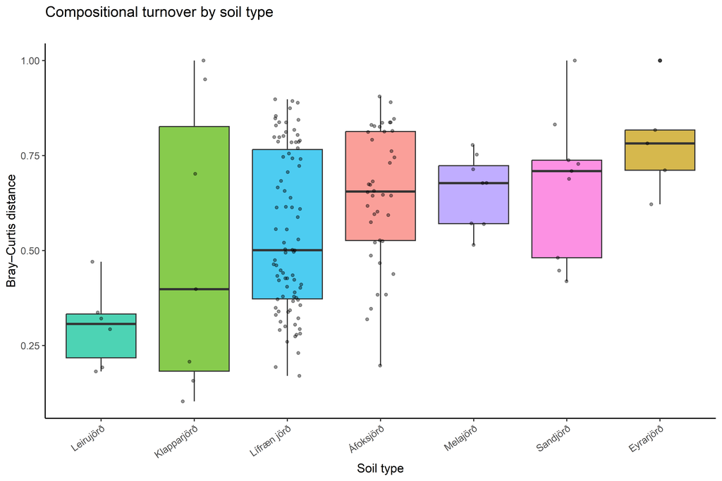

Per-plot Bray–Curtis distance (first → last survey) by soil type. Points are individual plots.

```r
if ("soil_type_name" %in% names(plot_bc_env)) {
  p_bc_soil <- ggplot(
    plot_bc_soil,
    aes(x = reorder(soil_type_name, bc_dist, FUN = median),
        y = bc_dist, fill = soil_type_name)
  ) +
    geom_boxplot(alpha = 0.7, outlier.size = 1.2) +
    geom_jitter(width = 0.15, alpha = 0.4, size = 1) +
    labs(
      title    = "Compositional turnover by soil type",
      subtitle = "Per-plot Bray–Curtis distance (first → last survey)",
      x = "Soil type", y = "Bray–Curtis distance", fill = NULL
    ) +
    theme_classic(base_size = 11) +
    theme(axis.text.x = element_text(angle = 35, hjust = 1),
          legend.position = "none")
} else {
  p_bc_soil <- ggplot() +
    theme_void() +
    ggtitle("Soil type not available in meta_strict / plot_bc_env")
}

p_bc_soil
```

# Part 4 — Indicator species analysis (IndVal)

```r
group_vec <- ifelse(meta_strict$sample == "first", 1L, 2L)

indval_result <- multipatt(
  mat_strict,
  cluster = group_vec,
  control = how(nperm = 999),
  func    = "IndVal.g",
  duleg   = TRUE
)

indval_tbl <- indval_result$sign %>%
  rownames_to_column("taxon") %>%
  as_tibble() %>%
  rename(group = index) %>%
  mutate(
    survey = if_else(group == 1L, "first", "last"),
    p_adj  = p.adjust(p.value, method = "BH")
  ) %>%
  filter(p.value <= 0.05) %>%
  arrange(p.value)
```

**21 taxa** pass raw permutation p ≤ 0.05: 15 associated with the **first** survey, 6 with the **last** survey.

## 4.1 Full indicator taxa table

```r
print_full(
  indval_tbl %>%
    select(taxon, survey, stat, p.value, p_adj) %>%
    mutate(sig = case_when(p.value < 0.001 ~ "***",
                           p.value < 0.01  ~ "**",
                           p.value < 0.05  ~ "*",
                           TRUE            ~ "ns")),
  caption = "Indicator taxa (IndVal.g, raw permutation p ≤ 0.05). 'first' = associated with first survey; 'last' = last survey. p_adj = BH correction (for reference)."
)
```

Indicator taxa (IndVal.g, raw permutation p ≤ 0.05). ‘first’ = associated with first survey; ‘last’ = last survey. p_adj = BH correction (for reference).

| taxon | survey | stat | p.value | p_adj | sig |
| --- | --- | --- | --- | --- | --- |
| Equisetum variegatum | first | 0.5534 | 0.001 | 0.0444 | ** |
| Salix arctica | last | 0.6148 | 0.001 | 0.0444 | ** |
| Festuca richardsonii | last | 0.4388 | 0.001 | 0.0444 | ** |
| Euphrasia frigida | first | 0.4797 | 0.001 | 0.0444 | ** |
| Cerastium alpinum | first | 0.4308 | 0.001 | 0.0444 | ** |
| Koenigia islandica | first | 0.3246 | 0.003 | 0.1110 | ** |
| Juncus biglumis | first | 0.2326 | 0.004 | 0.1269 | ** |
| Sagina nivalis | first | 0.3498 | 0.005 | 0.1388 | ** |
| Salix phylicifolia | last | 0.3613 | 0.006 | 0.1480 | ** |
| Empetrum nigrum | last | 0.6208 | 0.007 | 0.1554 | ** |
| Poa glauca | first | 0.3008 | 0.009 | 0.1816 | ** |
| Carex bigelowii | last | 0.5195 | 0.014 | 0.2590 | * |
| Luzula spicata | first | 0.4186 | 0.016 | 0.2732 | * |
| Minuartia stricta | first | 0.2457 | 0.022 | 0.3489 | * |
| Cryptogamic crust | last | 0.1930 | 0.028 | 0.3663 | * |
| Pedicularis flammea | first | 0.2292 | 0.028 | 0.3663 | * |
| Selaginella selaginoides | first | 0.2844 | 0.030 | 0.3663 | * |
| Minuartia rubella | first | 0.2221 | 0.031 | 0.3663 | * |
| Trichophorum cespitosum | first | 0.2195 | 0.033 | 0.3663 | * |
| Carex rupestris | first | 0.2219 | 0.033 | 0.3663 | * |
| Saxifraga nivalis | first | 0.2113 | 0.042 | 0.4440 | * |

Indicator species (IndVal.g) for first vs last survey. Columns: taxon, survey association (first/last), IndVal statistic (stat), raw permutation p‑value (p.value), BH-adjusted p_adj (for reference). All taxa listed pass raw p ≤ 0.05. The pattern aligns with thermophilisation: arctic‑alpine specialists (e.g. *Equisetum variegatum*, *Euphrasia frigida*, *Sagina nivalis*, *Cerastium alpinum*, *Koenigia islandica*) flag the first survey; competitive low‑shrub species (e.g. *Empetrum nigrum*, *Salix arctica*, *Carex bigelowii*) flag the last.

## 4.2 Top 15 per survey — bar chart

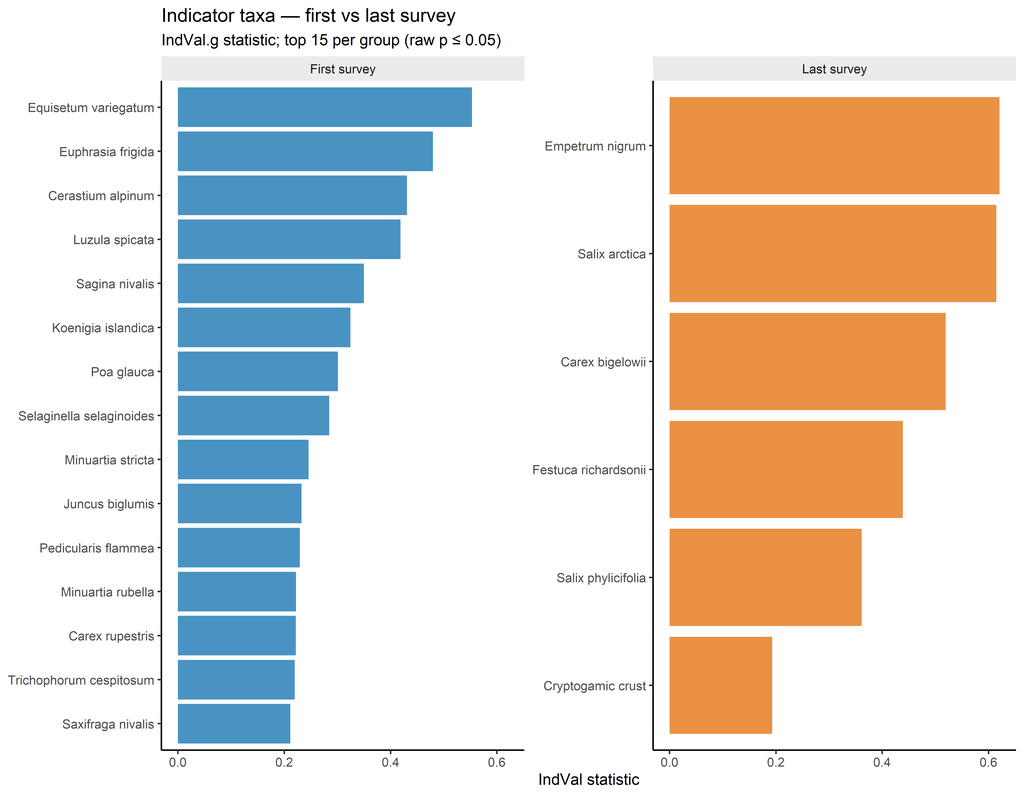

Top 15 indicator taxa per survey by IndVal.g statistic (raw p ≤ 0.05).

```r
top_indval <- indval_tbl %>%
  group_by(survey) %>%
  slice_min(order_by = p.value, n = 15, with_ties = FALSE) %>%
  ungroup()

if (nrow(top_indval) > 0 && length(unique(top_indval$survey)) > 0) {
  ggplot(top_indval,
         aes(x = stat, y = reorder(taxon, stat), fill = survey)) +
    geom_col(alpha = 0.85) +
    facet_wrap(
      ~survey,
      scales  = "free_y",
      labeller = as_labeller(c(first = "First survey", last = "Last survey"))
    ) +
    scale_fill_manual(values = c(first = "#2980b9", last = "#e67e22")) +
    labs(
      title    = "Indicator taxa — first vs last survey",
      subtitle = "IndVal.g statistic; top 15 per group (raw p ≤ 0.05)",
      x = "IndVal statistic", y = NULL, fill = NULL
    ) +
    theme_classic(base_size = 10) +
    theme(legend.position = "none",
          strip.background = element_rect(fill = "grey92", colour = NA))
} else {
  ggplot() +
    theme_void() +
    ggtitle("No indicator taxa to display (top_indval is empty)")
}
```

# Part 5 — Univariate change in community descriptors

Paired Wilcoxon signed-rank test for each continuous driver variable. Each plot contributes one matched pair (first survey value, last survey value).

```r
univar_vars <- intersect(
  c("haplontuthekja", "vegetation_height_mean", "total_cover", "soil_depth"),
  names(meta_strict)
)

if (length(univar_vars) == 0L) {
  stop("No univariate variables found in meta_strict. Check that at least one of haplontuthekja, vegetation_height_mean, total_cover, soil_depth exists.")
}

env_paired_wide <- meta_strict %>%
  select(plot_number, sample, all_of(univar_vars)) %>%
  pivot_wider(
    names_from  = sample,
    values_from = all_of(univar_vars),
    names_sep   = "_"
  )

wilcox_results <- map_dfr(univar_vars, function(v) {
  first_col    <- paste0(v, "_first")
  last_col     <- paste0(v, "_last")
  x            <- env_paired_wide[[first_col]]
  y            <- env_paired_wide[[last_col]]
  if (is.null(x) || is.null(y) || length(x) == 0L) {
    return(tibble(
      variable = v, n_pairs = 0L, median_first = NA_real_, median_last = NA_real_,
      median_change = NA_real_, ci_low = NA_real_, ci_high = NA_real_,
      W = NA_real_, p_value = NA_real_
    ))
  }
  complete_idx <- complete.cases(x, y)
  n_pairs      <- sum(complete_idx)
  if (n_pairs < 2L) {
    return(tibble(
      variable = v, n_pairs = n_pairs, median_first = median(x[complete_idx], na.rm = TRUE),
      median_last = median(y[complete_idx], na.rm = TRUE),
      median_change = median(y[complete_idx] - x[complete_idx], na.rm = TRUE),
      ci_low = NA_real_, ci_high = NA_real_, W = NA_real_, p_value = NA_real_
    ))
  }
  test <- wilcox.test(y[complete_idx], x[complete_idx],
                      paired = TRUE, conf.int = TRUE)
  tibble(
    variable      = v,
    n_pairs       = n_pairs,
    median_first  = median(x[complete_idx], na.rm = TRUE),
    median_last   = median(y[complete_idx], na.rm = TRUE),
    median_change = median(y[complete_idx] - x[complete_idx], na.rm = TRUE),
    ci_low        = test$conf.int[1],
    ci_high       = test$conf.int[2],
    W             = test$statistic,
    p_value       = test$p.value
  )
}) %>%
  mutate(
    p_adj = p.adjust(p_value, method = "BH"),
    sig   = case_when(p_adj < 0.001 ~ "***",
                      p_adj < 0.01  ~ "**",
                      p_adj < 0.05  ~ "*",
                      TRUE          ~ "ns")
  )
```

## 5.1 Results table

```r
print_full(wilcox_results,
           caption = "Paired Wilcoxon signed-rank test results. median_change = last − first. BH-adjusted p-values.")
```

Paired Wilcoxon signed-rank test results. median_change = last − first. BH-adjusted p-values.

| variable | n_pairs | median_first | median_last | median_change | ci_low | ci_high | W | p_value | p_adj | sig |
| --- | --- | --- | --- | --- | --- | --- | --- | --- | --- | --- |
| soil_depth | 0 | NA | NA | NA | NA | NA | NA | NA | NA | ns |

## 5.2 Change distributions

```r
# Guard: only loop over variables whose paired columns actually exist in env_paired_wide.
# A stale cache can produce env_paired_wide that is missing columns added since the last
# cache invalidation — clearing cache/v_plants_* fixes that permanently.
univar_vars_present <- univar_vars[
  paste0(univar_vars, "_first") %in% names(env_paired_wide) &
  paste0(univar_vars, "_last")  %in% names(env_paired_wide)
]

env_paired_long_change <- map_dfr(univar_vars_present, function(v) {
  first_col <- paste0(v, "_first")
  last_col  <- paste0(v, "_last")
  env_paired_wide %>%
    transmute(
      plot_number = plot_number,
      variable    = v,
      change      = .data[[last_col]] - .data[[first_col]]
    ) %>%
    filter(!is.na(change))   # filter here: 'change' is always present in this scope
}) %>%
  { if ("variable" %in% names(.))
      left_join(., wilcox_results %>% select(variable, p_adj, sig), by = "variable")
    else . }

if (nrow(env_paired_long_change) == 0) {
  message("univar-plot: no paired change data available — skipping plot.")
} else {
  y_top <- max(env_paired_long_change$change, na.rm = TRUE) * 1.07

  print(
    ggplot(env_paired_long_change, aes(x = variable, y = change)) +
      geom_hline(yintercept = 0, linetype = "dashed", colour = "grey50") +
      geom_violin(fill = "#bdc3c7", alpha = 0.5, trim = TRUE) +
      geom_boxplot(width = 0.18, fill = "white", outlier.size = 0.8) +
      geom_text(
        data = env_paired_long_change %>% distinct(variable, sig),
        aes(y = y_top, label = sig),
        size = 5, colour = "#c0392b"
      ) +
      labs(
        title    = "Change in continuous community descriptors (last − first)",
        subtitle = "Paired Wilcoxon; * p<0.05, ** p<0.01, *** p<0.001 (BH-adjusted)",
        x = NULL, y = "Change (last − first)"
      ) +
      theme_classic(base_size = 11)
  )
}
```

# Part 6 — Excluded coastal plots

With only 6 rows (3 plots × 2 surveys), NMDS is numerically unstable. PCoA (metric multidimensional scaling) is used instead.

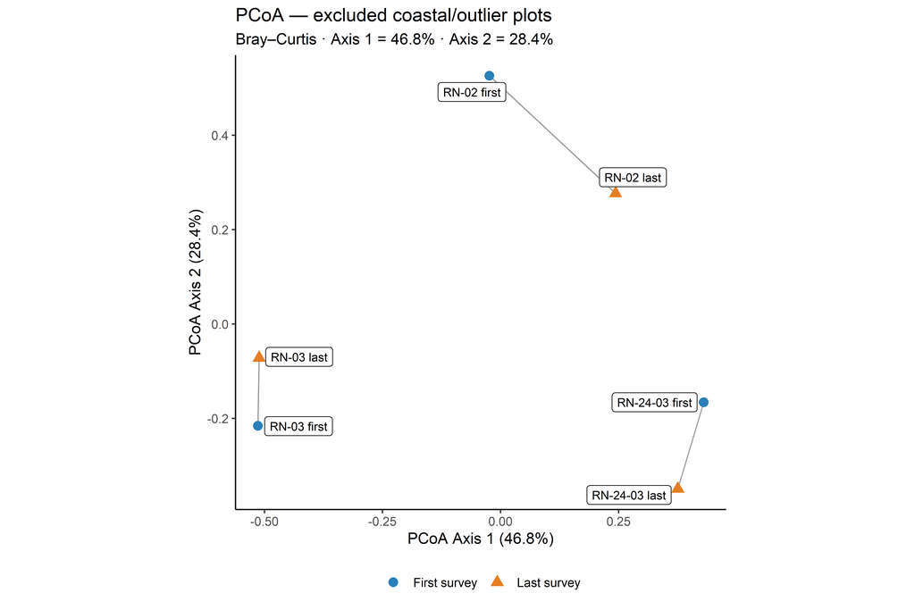

PCoA of the three excluded coastal/outlier plots. Labels show plot name and survey. Lines connect first and last survey of the same plot.

```r
outlier_rows <- meta_strict$plot_number %in% outlier_plots
mat_coastal  <- mat_strict[outlier_rows, ]
meta_coastal <- meta_strict[outlier_rows, ]
mat_coastal  <- mat_coastal[, colSums(mat_coastal) > 0]

pcoa_coastal <- cmdscale(
  vegdist(mat_coastal, method = "bray"),
  k   = 2,
  eig = TRUE
)

pcoa_df <- as.data.frame(pcoa_coastal$points) %>%
  setNames(c("Axis1", "Axis2")) %>%
  bind_cols(meta_coastal %>% select(plot_number, sample))

var_explained <- round(
  100 * pcoa_coastal$eig[1:2] / sum(abs(pcoa_coastal$eig)), 1
)

ggplot(pcoa_df, aes(x = Axis1, y = Axis2)) +
  geom_line(aes(group = plot_number), colour = "grey60", linewidth = 0.4) +
  geom_point(aes(colour = sample, shape = sample), size = 3) +
  geom_label_repel(
    aes(label = paste(plot_number, sample)),
    size = 3, max.overlaps = 20, seed = 1
  ) +
  scale_colour_manual(values = c(first = "#2980b9", last = "#e67e22"),
                      labels = c(first = "First survey", last = "Last survey")) +
  scale_shape_manual(values  = c(first = 16, last = 17),
                     labels  = c(first = "First survey", last = "Last survey")) +
  coord_equal() +
  labs(
    title    = "PCoA — excluded coastal/outlier plots",
    subtitle = sprintf("Bray–Curtis · Axis 1 = %.1f%% · Axis 2 = %.1f%%",
                       var_explained[1], var_explained[2]),
    x = sprintf("PCoA Axis 1 (%.1f%%)", var_explained[1]),
    y = sprintf("PCoA Axis 2 (%.1f%%)", var_explained[2]),
    colour = NULL, shape = NULL
  ) +
  theme_classic(base_size = 11) +
  theme(legend.position = "bottom")
```

```r
# Top species in each coastal plot (last survey only, for brevity)
coastal_last <- meta_coastal %>%
  filter(sample == "last") %>%
  pull(plot_number)

coastal_species <- community_long_paired %>%
  filter(plot_number %in% coastal_last, sample == "last") %>%
  arrange(plot_number, desc(cover)) %>%
  group_by(plot_number) %>%
  slice_head(n = 10) %>%
  ungroup()

print_full(coastal_species,
           caption = "Top 10 species by cover in each coastal plot (last survey).")
```

Top 10 species by cover in each coastal plot (last survey).

| plot_number | sample | taxon_name | cover |
| --- | --- | --- | --- |
| RN-02 | last | Leymus arenarius | 1.9000 |
| RN-03 | last | Honckenya peploides | 38.6667 |
| RN-03 | last | Mertensia maritima | 24.4000 |
| RN-03 | last | Leymus arenarius | 16.8333 |
| RN-03 | last | Cakile maritima | 0.8000 |
| RN-24-03 | last | Armeria maritima | 3.9800 |
| RN-24-03 | last | Silene uniflora | 0.4000 |
| RN-24-03 | last | Leymus arenarius | 0.3000 |
| RN-24-03 | last | Plantago maritima | 0.3000 |
| RN-24-03 | last | Silene acaulis | 0.3000 |
| RN-24-03 | last | Thymus praecox | 0.3000 |

# Part 7 — Suggested next steps

Based on the results above, the following analyses are the logical continuation — choose based on what the figures showed.

**A — dbRDA (distance-based redundancy analysis)** If haplontuthekja or vegetation height changed significantly in Part 5, use dbRDA to formally partition variance between the temporal effect (*sample*) and the environmental gradient, while conditioning on plot identity:

```r
vegan::dbrda(
  mat_strict ~ sample + haplontuthekja + Condition(plot_number),
  data   = meta_strict,
  method = "bray"
)
```

**B — Stratum-specific PERMANOVAs** If soil type or moisture was significant in the Kruskal–Wallis (Part 3), split the dataset by those classes and re-run paired PERMANOVA within each stratum — this tests whether the temporal signal is consistent across habitat types or concentrated in one.

**C — Taxon-level ecology** Review the indicator taxa from Part 4 against Icelandic vegetation literature. Key questions: - Are the ‘last survey’ gainers typically associated with warming, reduced grazing, or nitrogen deposition in Icelandic heathlands? - Do *Racomitrium* or *Dryas* appear as consistent losers? - Are wetland sedges (*Carex lyngbyei*, *C. nigra*) showing directional change?

**D — Spatial autocorrelation of turnover** Test whether compositional change (the per-plot Bray–Curtis from Part 3) is spatially structured using a Mantel test:

```r
geo_dist <- dist(cbind(env_first$longitude_1, env_first$latitude_1))
vegan::mantel(bc_dist_matrix, geo_dist, method = "pearson", permutations = 999)
```